# Variations smashing Voronoi

For this piece I use the following packages:

```r
library(dplyr) # A Grammar of Data Manipulation
library(ggplot2) # Create Elegant Data Visualisations Using the Grammar of Graphics
library(glue) # Interpreted String Literals
library(gsubfn) # Utilities for Strings and Function Arguments
library(lwgeom) # Bindings to Selected 'liblwgeom' Functions for Simple Features
library(MetBrewer) # Color Palettes Inspired by Works at the Metropolitan Museum of Art
library(MexBrewer) # Color Palettes Inspired by Works of Mexican Muralists
library(rayshader) # Create Maps and Visualize Data in 2D and 3D
library(stringr) # Simple, Consistent Wrappers for Common String Operations
library(sf) # Simple Features for R # Simple Features for R
```

## Generate a random seed

```r
seed <- sample.int(100000000, 1)
#seed <- 92626956
```

## Bounding box

Create a bounding box to contain the spiral:

```r
bbox <- matrix(c(-10, -10,
                 -10, 10,
                 10, 10,
                 10, -10,
                 -10, -10),
               ncol = 2,
               byrow = TRUE)

# Convert coordinates to polygons and then to simple features
bbox <- data.frame(id = 1,
                   geometry = st_polygon(list(bbox)) |>
                     st_sfc()) |>
  st_as_sf()
```

## Points for tessellation

The generative process is a spiral. The following chunk of code implements two types of spirals: An Archimedean spiral, or a [phyllotactic spiral](https://www.r-bloggers.com/2019/01/playing-around-with-phyllotactic-spirals/) with a randomly chosen angle:

```r
set.seed(seed)

if(sample(c(TRUE, FALSE), 1)){
  # Archimedean spiral
  k <- sample.int(4, 1)

  sprl <- data.frame(t = seq(0, 10, 0.05)) |>
    mutate(id = 1:n(),
           x_sp = t * cos((5 + k) * t),
           y_sp = t * sin((5 + k) * t),
           x = t * cos((5 + k) * t),
           y = t * sin((5 + k) * t)) |>
    st_as_sf(coords = c("x", "y"))
}else{
  # Number of points for the spiral; this parameter is the square of the radius of the spiral
  n <- 300

  # Choose an angle
  angle <- sample(c("pi*(3-sqrt(5))", # Golden angle
                    "sqrt(2)",
                    "sqrt(3)",
                    "sqrt(5)",
                    "pi/7",
                    "pi/9",
                    "pi/46",
                    "2",
                    "2"),
                  1)

  eval(parse(text = paste0("angle <-", angle)))

  theta <- runif(1, 0, 2 * pi)

  # Data frame with spiral points is converted to simple features
  sprl <- data.frame(
    idx = c(0:(n-1))) |> ## you can increase the number here to use more lines.
    mutate(t = seq(0,2*pi,length.out=n()),  ## since I used 0 to 1800 above, need to add 1
           r = sqrt(idx), ## radius
           x_sp = r * cos(theta * angle * idx),
           y_sp = r * sin(theta * angle * idx),
           x = r * cos(theta * angle * idx),
           y = r * sin(theta * angle * idx),
           color_angle = atan2(y = y,
                               x = x) ## get angle between x-axis and the vector from the origin to x,y
    )  |>
    st_as_sf(coords = c("x", "y"))
}
```

Plot the base spiral:

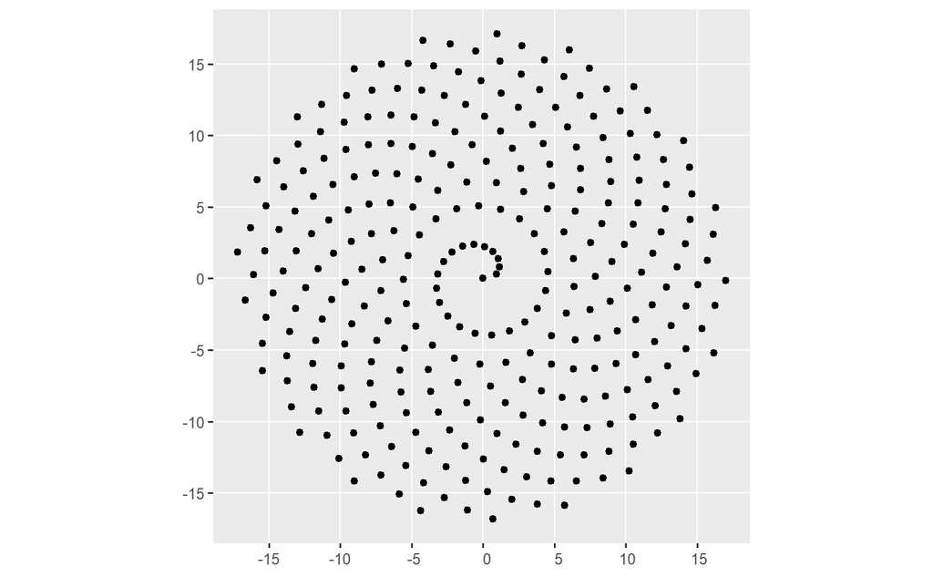

```r
ggplot() +
  geom_sf(data = sprl)
```

Use the points of the spiral to create a Voronoi tessellation:

```r
# The function `do.call(what, arg)` applies a function
# `what` to the argument `arg`. In this case, we extract
# the geometry of the `sf` object (i.e., the coordinates
# of the points) and apply the function `c()` to concatenate
# the coordinates to obtain a MULTIPOINT object.
# The pipe operator passes the MuLTIPOINT object to function `st_voronoi()`
sprl_v<- do.call(c, st_geometry(sprl)) %>%
  st_voronoi() %>%
  # The output of `st_voronoi()` is a collection of geometries,
  # which we pass to the following function for extraction.
  st_collection_extract()

sprl_v <- sprl |>
  st_set_geometry(st_geometry(sprl_v)) |>
  st_intersection(bbox)
coords <- sprl_v |>
  st_centroid() |>
  st_coordinates()
sprl_v <- sprl_v |>
  mutate(x_v = coords[,1],
         y_v = coords[,2],
         id.1 = 0)
```

```r
sprl_b2 <- sprl_v |>
  st_buffer(dist = c(-0.04)) |>
  mutate(id.1 = 2)

sprl_b3 <- sprl_v |>
  st_buffer(dist = c(-0.06)) |>
  mutate(id.1 = 3)

sprl_b4 <- sprl_v |>
  st_buffer(dist = c(-0.08)) |>
  mutate(id.1 = 4)

sprl_b5 <- sprl_v |>
  st_buffer(dist = c(-0.10)) |>
  mutate(id.1 = 5)
```

```r
#ggplot() +
#  geom_sf(data = sprl_b)
```

## L-system

A. Sanchez Chinchón defines these terms in a [blog post](https://fronkonstin.com/2017/07/18/plants/). Briefly, the *axiom* is the seed of the drawing: it says what rules to apply and in what order. The rules indicate the actions involved in the axiom. Here “F” is “draw a one-unit line”; “+” and “-” indicate right and left turns by the stipulated angle; “[” and ”]” mean setting a checkpoint and returning to the most recent checkpoint; and the depth is the number of times that the axiom will be implemented.

```r
set.seed(seed)

# The shattering
axiom <- "X"
rules <- list("X"="FF[+XF][-XF]FFF", "F"="F")
angle <- runif(5, 30, 70)
depth <- 8

# Expand the axiom by the depth
for (i in 1:depth) axiom <- gsubfn(".",
                                   rules,
                                   axiom)

# Extract the actions from the axiom
actions <- axiom |>
  str_extract_all("\\d*\\+|\\d*\\-|F|L|R|\\[|\\]|\\|") |>
  unlist()

# Initialize the status or check point
status <- data.frame(x = numeric(0),
                     y = numeric(0),
                     alfa = numeric(0))

# Initialize the points for the drawing. Here, I start at y = -5 because that more or less centers the L-system at origin of the spiral
points <- data.frame(x1 = 0,
                     y1 = -5,
                     x2 = NA,
                     y2 = NA,
                     alfa = 90,
                     depth = 1)
```

Implement the recursive algorithm to generate the L-system:

```r
set.seed(seed)

for (action in actions){
  if (action == "F")
  {
    x <- points[1, "x1"] + cos(points[1, "alfa"] * (pi/180))
    y <- points[1, "y1"] + sin(points[1, "alfa"] * (pi/180))
    points[1, "x2"] <- x
    points[1, "y2"] <- y
    points <- data.frame(x1 = x,
                         y1 = y,
                         x2 = NA,
                         y2 = NA,
                         alfa = points[1, "alfa"],
                         depth = points[1,"depth"]) |>
      rbind(points)
  }
  if (action %in% c("+", "-")){
    alfa <- points[1, "alfa"]
    points[1, "alfa"] <- eval(parse(text = paste0("alfa", action, sample(angle, 1))))
  }
  if(action=="["){
    status <- data.frame(x = points[1, "x1"],
                         y = points[1, "y1"],
                         alfa = points[1, "alfa"]) |>
      rbind(status)
    points[1, "depth"] <- points[1, "depth"] + 1
  }

  if(action=="]"){
    depth <- points[1, "depth"]
    points <- points[-1,]
    points <- data.frame(x1 = status[1, "x"],
                         y1 = status[1, "y"],
                         x2 = NA,
                         y2 = NA,
                         alfa = status[1, "alfa"],
                         depth = depth - 1) |>
      rbind(points)
    status <- status[-1,]
  }
}
```

Plot the L-system:

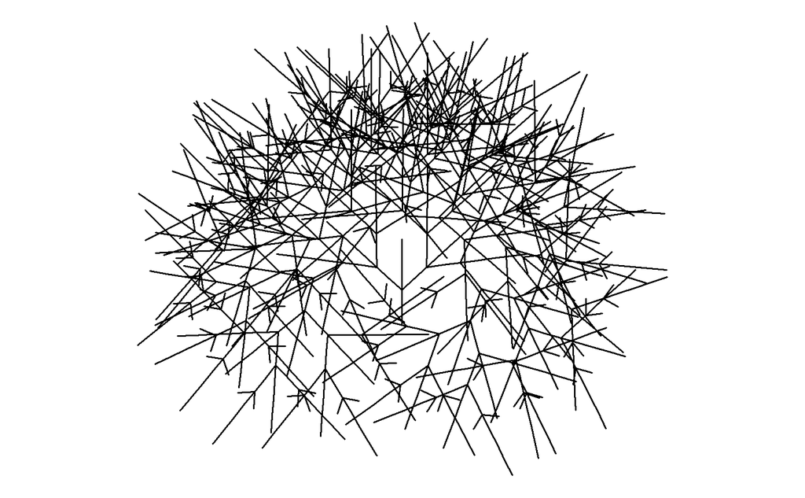

```r
ggplot() +
  geom_segment(aes(x = x1,
                   y = y1,
                   xend = x2,
                   yend = y2),
               lineend = "round",
               colour="black",
               data=na.omit(points)) +
  coord_fixed(ratio = 1) +
  theme_void()
```

Convert the L-system to simple features:

```r
# Extract the coordinates of the starting points of the lines
begin.coord <- points |>
  # Exclude the first point (it has non end-point)
  slice_tail(n = nrow(points) - 1) |>
  select(x1, y1) |>
  rename(x = x1, y = y1)

# Extract the coordinates of the end points of the lines
end.coord <- points |>
  # Exclude the first point (it has non end-point)
  slice_tail(n = nrow(points) - 1) |>
  select(x2, y2) |>
  rename(x = x2, y = y2)

# Create list of simple feature geometries (linestrings)
l_sf <- vector("list", nrow(begin.coord))
for (i in seq_along(l_sf)){
  l_sf[[i]] <- st_linestring(as.matrix(rbind(begin.coord[i, ], end.coord[i,])))
}

# Convert to simple features
l_sf <- l_sf |>
  st_as_sfc()
```

Take the bounding box and split it using the lines of the L-system:

```r
l_sf <- bbox |>
  st_split(l_sf) |>
  st_collection_extract(c("POLYGON"))
```

Plot the split bounding box:

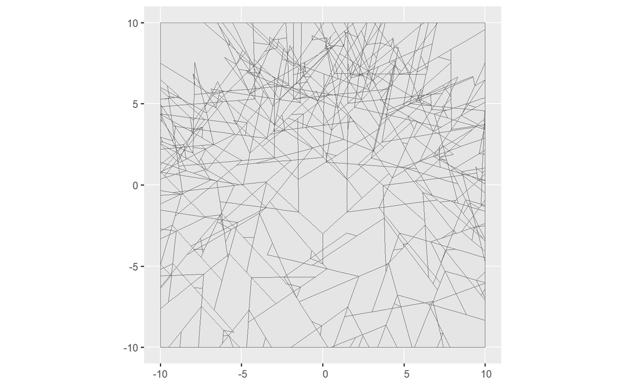

```r
ggplot() +
  geom_sf(data = l_sf)
```

## Smash the tessellation

To “smash” the tessellation, intersect the voronoi polygons with the split bounding box:

```r
# Intersect the Voronoi polygons and the L-system
sprl_b5 <- sprl_b5 |>
  st_intersection(l_sf)
# Cast to polygons
#prl <- data.frame(geometry = sprl) |>
#  mutate(id = 1:n()) |>
#  st_as_sf() |>
#  st_cast(to = "POLYGON")

# Extract the coordinates of the centroids of the polygons; these values can be used to choose the colors
coords <- st_centroid(sprl_b5) |>
  st_coordinates()
sprl_b5 <- sprl_b5 |>
  mutate(x_sm = coords[,1],
         y_sm = coords[,2]) |>
  select(-id.2)



sprl_b <- rbind(sprl_v |>
                  mutate(x_sm = x_sp,
                         y_sm = y_sp),
                sprl_b2|>
                  mutate(x_sm = x_sp,
                         y_sm = y_sp),
                sprl_b3|>
                  mutate(x_sm = x_sp,
                         y_sm = y_sp),
                sprl_b4|>
                  mutate(x_sm = x_sp,
                         y_sm = y_sp),
                sprl_b5)

sprl_b <- sprl_b |>
  mutate(x_sm = ifelse(id.1 == 5, x_sm * runif(n(), 0.94, 1.05), x_sm),
         y_sm = ifelse(id.1 == 5, x_sm * runif(n(), 0.94, 1.05), y_sm),
         fill = 0.75 * sqrt((x_sm + id.1)^2 + (y_sm + id.1)^2))
```

Choose a schema for coloring the polygons, based on the coordinates of the voronoi polygons or the smashed polygons:

```r
# set.seed(seed)
#
# fill_schema <- sample(c("spiral", "voronoi", "smashed"), 1)
#
# # Add the coordinates of the polygon centroids and create a variable for the fill
# sprl_b <- sprl_b |>
#   mutate(fill = case_when(fill_schema == "spiral" ~ 0.75 * sqrt((x_sp + id.1)^2 + (y_sp + id.1)^2) * runif(n(), 0.94, 1.05),
#                           fill_schema == "voronoi" ~ 0.75 * sqrt((x_v + id.1)^2 + (y_v + id.1)^2) * runif(n(), 0.94, 1.05),
#                           fill_schema == "smashed" ~ 0.75 * sqrt((x_sm + id.1)^2 + (y_sm + id.1)^2) * runif(n(), 0.94, 1.05)))
```

[figure not shown]

## Render

Randomly select a color palette from package [{MexBrewer}](https://paezha.github.io/MexBrewer/) or [{MetBrewer}](https://CRAN.R-project.org/package=MetBrewer):

```r
set.seed(seed)

color_edition <- sample(c("MetBrewer", "MexBrewer"), 1)

if(color_edition == "MetBrewer"){
  col_palette_name <- sample(c("Archambault", "Austria", "Benedictus", "Cassatt1", "Cassatt2", "Cross", "Degas", "Demuth", "Derain", "Egypt", "Gauguin", "Greek", "Hiroshige", "Hokusai1", "Hokusai2", "Hokusai3", "Homer1", "Homer2", "Ingres", "Isfahan1", "Isfahan2", "Java", "Johnson", "Juarez", "Kandinsky", "Klimt", "Lakota", "Manet", "Moreau", "Morgenstern", "Nattier", "Navajo", "NewKingdom", "Nizami", "OKeeffe1", "OKeeffe2", "Paquin", "Peru1", "Peru2", "Pillement", "Pissaro", "Redon", "Renoir", "Signac", "Tam", "Tara", "Thomas", "Tiepolo", "Troy", "Tsimshian", "VanGogh1", "VanGogh2", "VanGogh3", "Veronese", "Wissing"), 1)
}else{
  col_palette_name <- sample(c("Alacena", "Atentado", "Aurora", "Casita1", "Casita2", "Casita3", "Concha", "Frida", "Huida", "Maiz", "Ofrenda", "Revolucion", "Ronda", "Taurus1", "Taurus2", "Tierra", "Vendedora"), 1)
}
```

Create plot:

```r
set.seed(seed)

p <- ggplot() +
  geom_sf(data = sprl_b,# |>
          #st_intersection(container_polygon),
          aes(fill = fill),
          color = NA)
if(color_edition == "MetBrewer"){
  p <- p +
    scale_fill_met_c(col_palette_name,
                     direction = sample(c(-1, 1), 1)) +
    theme(legend.position = "none",
          axis.text = element_text(color = "white"),
          panel.background = element_rect(fill = "white"),
          axis.ticks = element_line(color = "white"))
}else{
  p <- p +
    scale_fill_mex_c(col_palette_name,
                     direction = sample(c(-1, 1), 1)) +
    theme(legend.position = "none",
          axis.text = element_text(color = "white"),
          panel.background = element_rect(fill = "white"),
          axis.ticks = element_line(color = "white"))
}
```

Convert the ggplot object to a 3D image using {rayshader} and save:

```r
plot_gg(p,
        phi = 90,
        theta = 0,
        pointcontract = 0,
        height_aes = "fill",
        raytrace = TRUE,
        windowsize = c(4000, 4000))

# Save image
rgl::snapshot3d(glue("outputs/smashing-tessellations-{seed}.png"),
                fmt = 'png',
                webshot = TRUE,
                width = 2100,
                height = 2100)

# Close rgl device
rgl::rgl.close()
```

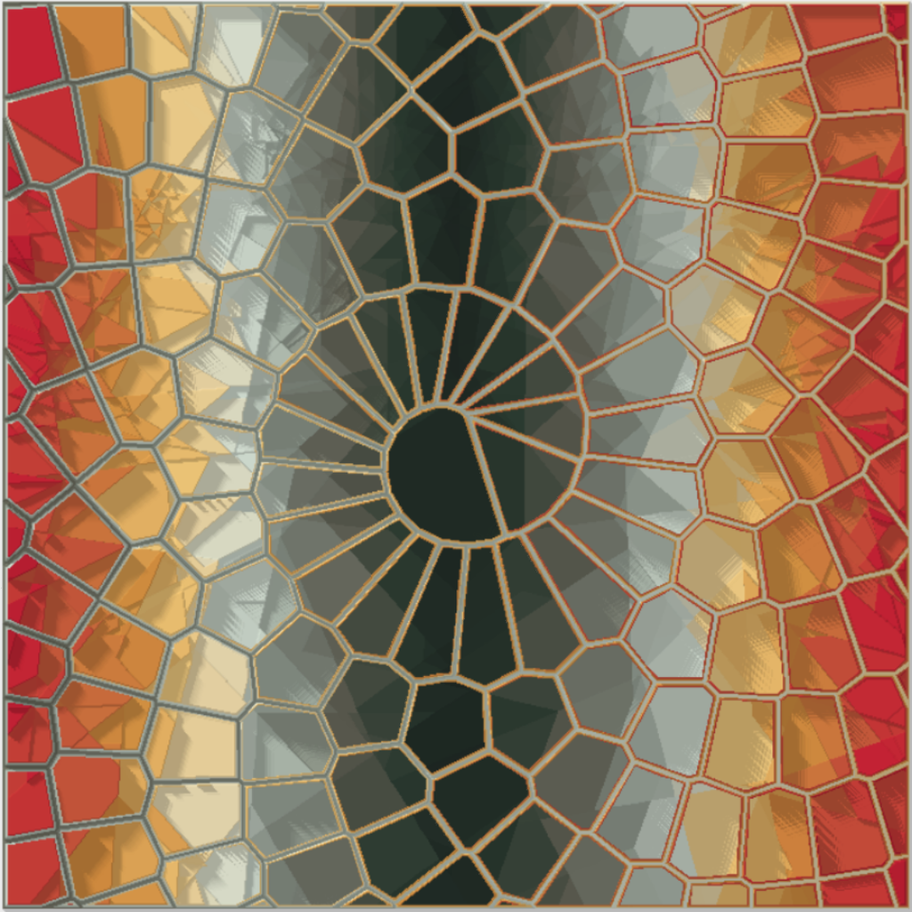